# Homework 1 template

### b.

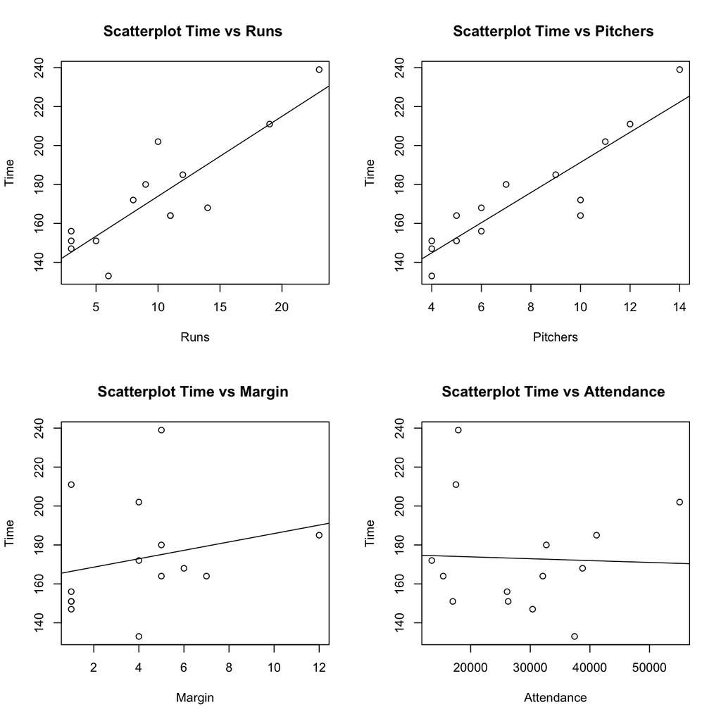

```r
new_BaseballTimes = BaseballTimes[-15,] #New table with omitted NYM-PHI row.

par(mfrow=c(2,2))#This puts plots in a 2x2 grid, which takes up less space.  You don't need to use it, but you may find it useful!
#Here you should have the plot(s) that you use to answer the question.

#Scatterplots
nsimplereg = lm(Time~Runs, data=new_BaseballTimes) # Create linear line to see the relationship between runs and time variable
plot(Time~Runs, data = new_BaseballTimes, main="Scatterplot Time vs Runs ")  #Draw scatter points
abline(reg=nsimplereg) #Draw linear line into graph

nsimplereg_2 = lm(Time~Pitchers, data=new_BaseballTimes) # Create linear line to see the relationship between pitchers and time variable
plot(Time~Pitchers,data = new_BaseballTimes, main="Scatterplot Time vs Pitchers ")  #Draw scatter points
abline(reg=nsimplereg_2) #Draw linear line into graph


nsimplereg_3 = lm(Time~Margin, data=new_BaseballTimes) # Create linear line to see the relationship between margin and time variable
plot(Time~Margin, data = new_BaseballTimes, main="Scatterplot Time vs Margin ")  #Draw scatter points
abline(reg=nsimplereg_3) #Draw linear line into graph

nsimplereg_4 = lm(Time~Attendance, data=new_BaseballTimes) # Create linear line to see the relationship between attendance and time variable
plot(Time~Attendance, data = new_BaseballTimes, main="Scatterplot Time vs Attendance ")  #Draw scatter points
abline(reg=nsimplereg_4) #Draw linear line into graph
```

- From above graph we can say that time and pitchers still have strong and postive correlation since we see that most of the points are really close to the line, and there are some points belong to the line.
- Runs is a another good factor but it isn’t good as Pitcher since there are many points stay far away from the line.
- Margin and Attendance are two bad factors since the linear regression line cannot present the relationship between factors and Time.

```r
#summary information about linear regression model
summary(nsimplereg_2)
```

```
##
## Call:
## lm(formula = Time ~ Pitchers, data = new_BaseballTimes)
##
## Residuals:
##     Min      1Q  Median      3Q     Max
## -27.330  -3.659   2.535   7.277  16.685
##
## Coefficients:
##             Estimate Std. Error t value Pr(>|t|)
## (Intercept)  113.869      8.852   12.86 2.22e-08 ***
## Pitchers       7.746      1.068    7.25 1.01e-05 ***
## ---
## Signif. codes:  0 '***' 0.001 '**' 0.01 '*' 0.05 '.' 0.1 ' ' 1
##
## Residual standard error: 12.79 on 12 degrees of freedom
## Multiple R-squared:  0.8141, Adjusted R-squared:  0.7987
## F-statistic: 52.57 on 1 and 12 DF,  p-value: 1.014e-05
```

- We can see that the new coefficient is 113.869, which is ~ 20% higher than the old coefficient 94.843. It means that this new model has changed a lot by omitting the outliner.

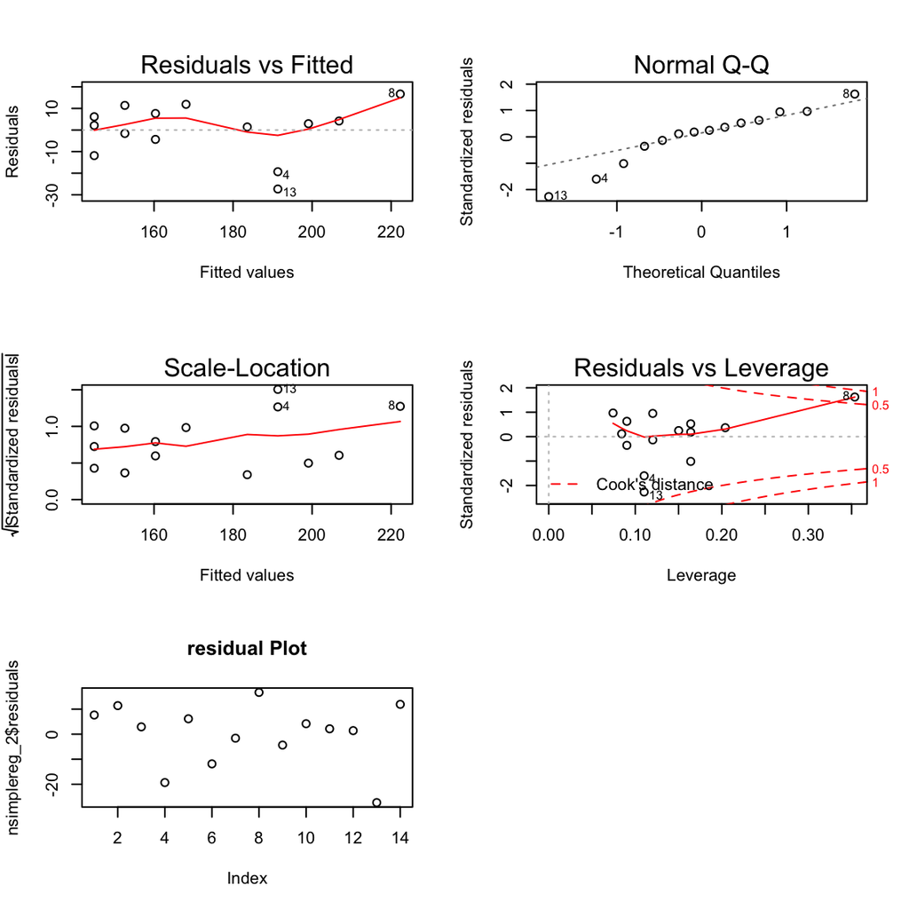

```r
#residual Plot
par(mfrow=c(3,2))
plot(nsimplereg_2)
plot(nsimplereg_2$residuals,main="residual Plot")
```

- The Normal Q-Q graph show that this model is a long-tailed residuals. It looks questionalble about the normality of the relationship between the model and data. The reason it looks nonormal maybe because of the sample is lack of randomness and data (there are only 14 objects).